# Time Series Graphics exercises - HW1

##### Chapter 2 HA 1 and 3

1. 2.1 Use the help function to explore what the series (`gold`), (`woolyrnq`) and (`gas`) represent.

The time dimension of this dataset being daily, isn’t setup to identify seasonality or year-over-year trends, so this type of evaluation has not been done. It is possible to transform the dataset with different granuality of the time dimension in order to reveal such trends.

```r
help(gold)
# Description:  "Daily morning gold prices in US dollars. 1 January 1985 – 31 March 1989."
# Usage:        "gold"
# Format:        "Time series data"

describe(gold)
```

```
##    vars    n   mean    sd median trimmed   mad min   max range  skew
## X1    1 1074 392.53 56.61 403.23  393.04 77.35 285 593.7 308.7 -0.11
##    kurtosis   se
## X1    -1.23 1.73
```

```r
head(gold)
```

```
## Time Series:
## Start = 1
## End = 6
## Frequency = 1
## [1] 306.25 299.50 303.45 296.75 304.40 298.35
```

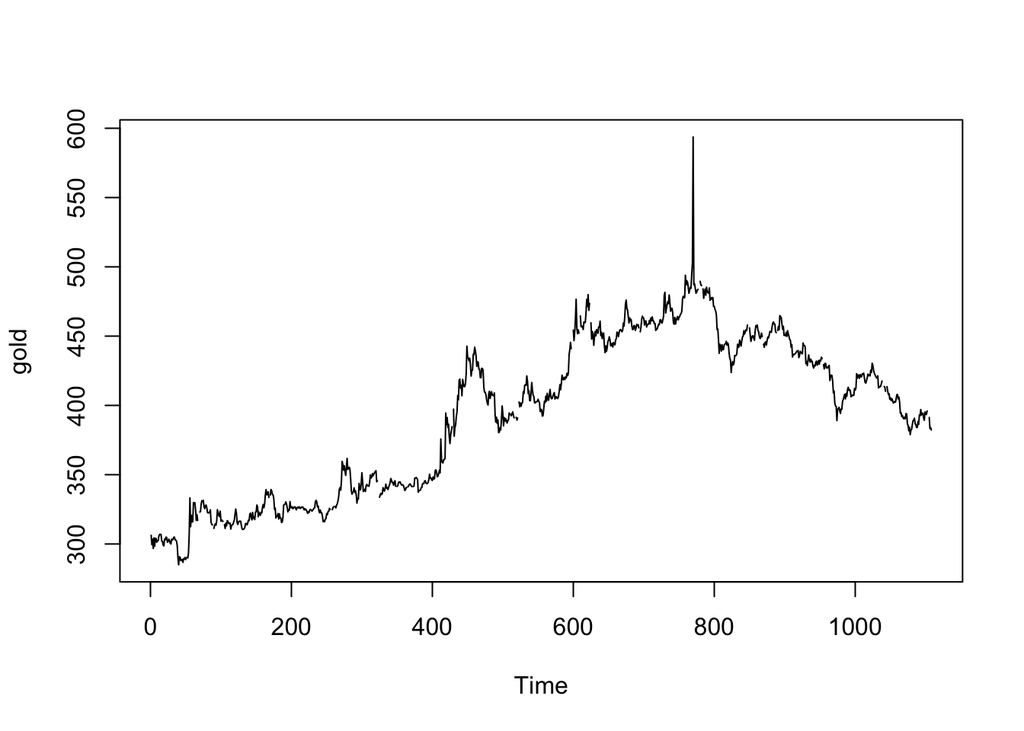

```r
plot(gold)
```

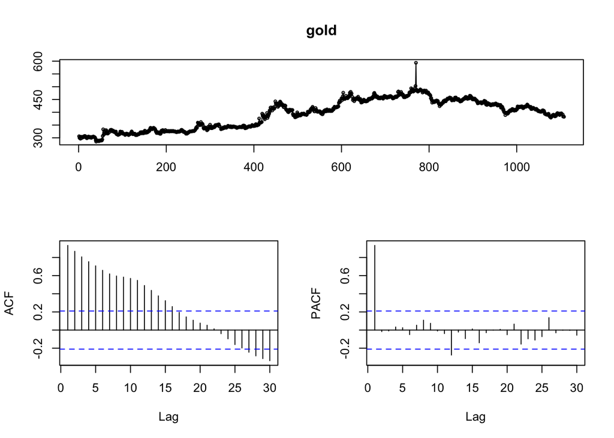

```r
tsdisplay(gold)
```

### Evaluation of *wool*

The `wool` dataset is not structured as a timeseries object but this is easily remedied. It is clear from inspecting the data that the time dimension is quarterly beginning in 1965. The ts (timeseries) function converts the data so seasonality or year-over-year analysis is possible. It isn’t clear what the `measure` dimension is capturing but perhaps it represents unit price or amount produced. In any case the trend shows an inital rise during the late 1960’s followed by a greater drop during the 1970’s and early 1980’s, some fluctuation in the later 1980’s early 1990’s followed by a spike in the mid 1990’s. The seasonality plots show peaks in Q3 and nadirs in Q1.

The lag plots show slight diminishing ACF trend with cyclical seasonal fluctuation and cyclical PACF with a diminishing magnitude.

```r
wool <- ts(woolyrnq, start=1965, frequency=4)
describe(wool)
```

```
##    vars   n    mean      sd median trimmed     mad  min  max range skew
## X1    1 119 5658.23 1040.75   5466 5652.27 1046.72 3324 7819  4495 0.15
##    kurtosis    se
## X1    -0.93 95.41
```

```r
head(wool)
```

```
##      Qtr1 Qtr2 Qtr3 Qtr4
## 1965 6172 6709 6633 6660
## 1966 6786 6800
```

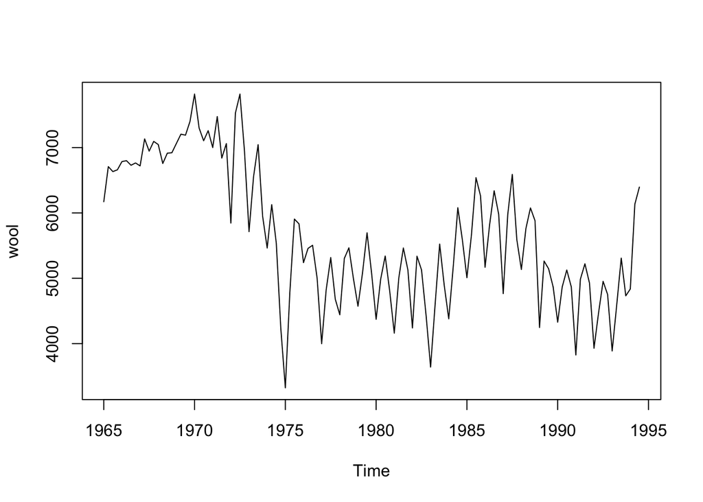

```r
plot(wool)
```

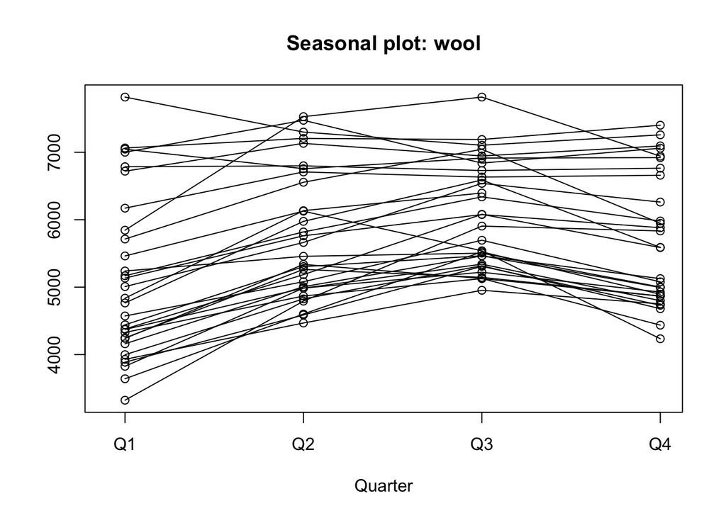

```r
seasonplot(wool)
```

```r
help(wool)
```

```
## No documentation for 'wool' in specified packages and libraries:
## you could try '??wool'
```

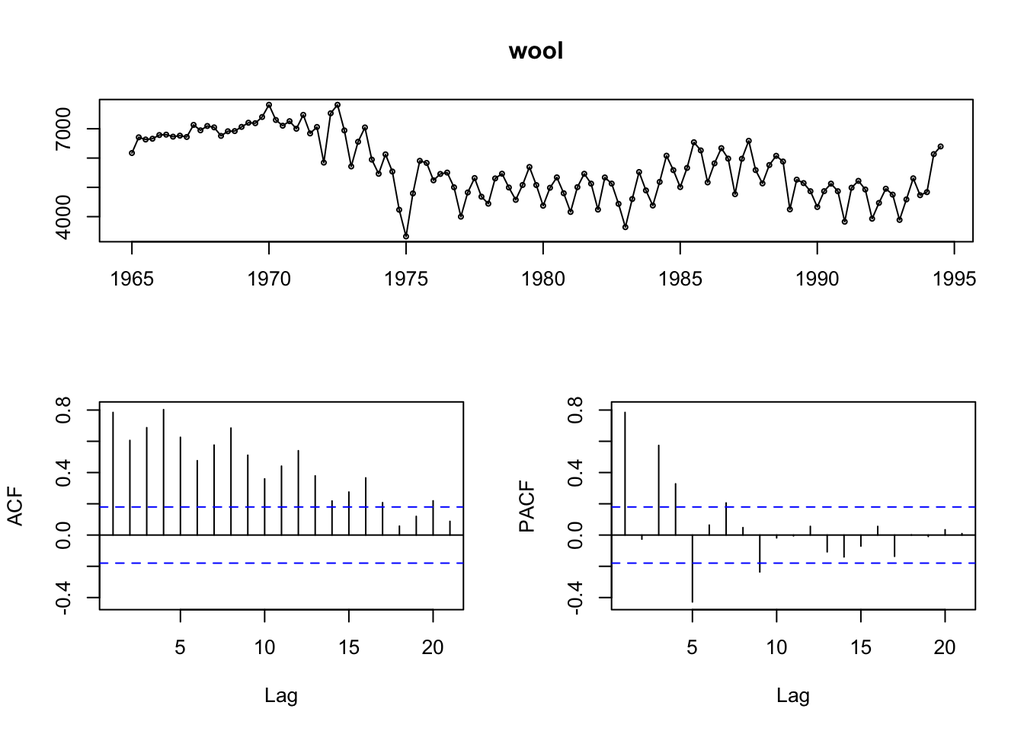

```r
tsdisplay(wool)
```